# SOK-1005: Prosjektoppgave Vår 2022

For å kunne laste inn og bearbeide dataen lastes nødvendige pakker inn.

```r
library(tidyverse)
library(jsonlite)
library(lubridate)
```

Deretter lastes dataene ned

```r
  AppWichStoresAttributes <- read.csv("https://data.mendeley.com/public-files/datasets/6htjnfs78b/files/26afd5e7-90b1-4301-ac5e-5905b38c4ec2/file_downloaded")
  county_crime <- read.csv("https://data.mendeley.com/public-files/datasets/6htjnfs78b/files/3691994e-2874-4ee6-b215-12e130c96175/file_downloaded")
  county_demographic <- read.csv("https://data.mendeley.com/public-files/datasets/6htjnfs78b/files/527e7486-7233-460a-99e0-3529b7cd7d49/file_downloaded")
  county_employment <- read.csv("https://data.mendeley.com/public-files/datasets/6htjnfs78b/files/846ac757-721e-4fd9-a414-5871f60de093/file_downloaded")
  weekly_sales_10stores <- read.csv("https://data.mendeley.com/public-files/datasets/6htjnfs78b/files/b963fdd1-0df9-4257-bd62-65256ec9d57c/file_downloaded")
  weekly_weather <- read.csv("https://data.mendeley.com/public-files/datasets/6htjnfs78b/files/b8708b3c-c5e8-456e-83f4-9f23f472a840/file_downloaded")
```

# Oppgave 1

Ikke alle datasettene er strukturert slik at det er mulig å slå de sammen som de er, derfor må vi endre noen kollonnenavn. I tillegg har datasettene for salg og vær forskjellig struktur på datovariabel, disse gjør vi lik.

```r
weekly_sales_10stores$Date <- mdy(weekly_sales_10stores$Date)

weekly_weather$Weather_Date <- dmy(weekly_weather$Weather_Date)

weekly_weather <- rename(weekly_weather, Store_Weather_Station = Weather_Station)
```

Rydder opp i de andre datasettene slik at de også er mulig å slå sammen.

```r
AppWichStoresAttributes <- AppWichStoresAttributes %>%
  rename(County_Name = Store_County)

weekly_sales_10stores <- weekly_sales_10stores %>%
  rename(Store_Num = Store_num)

weekly_weather <- weekly_weather %>%
  rename(Date = Weather_Date)
```

```r
DF1 <- merge(AppWichStoresAttributes, weekly_weather, by ="Store_Weather_Station")
DF2 <- merge(DF1, county_crime, by ="County_Name")
DF3 <- merge(DF2, county_demographic, by ="County_Name")
DF4 <- merge(DF3, county_employment, by ="County_Name")
DF5 <- left_join(DF4, weekly_sales_10stores, by = c("Store_Num", "Date"))
```

Til stlutt så fjerner vi noen unødvendige variabler i det kombinerete datasettet.

```r
all <- DF5 %>%
  select(-Year,-Day) %>%
  rename(Week = Weather_Week)
```

# Oppgave 2

For å lage en ukentlig salgsrapport velger vi å se på bedrift nummer 2. Denne blir omtalt som Power City FreeStanding og vi velger ut navn, datoer, uke og profit for å plotte.

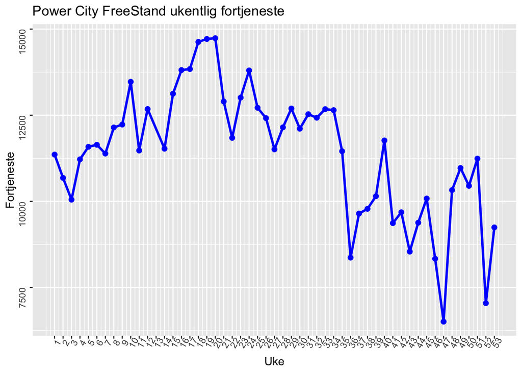

```r
PCFS <- all %>% filter(Store_Num=="2") %>%
  select(Store_Name,Date,Week,Profit)

WeekSumPCFS <-
  aggregate(PCFS$Profit,
            by=list(Week=PCFS$Week),
            FUN=sum) %>%
  rename(Profit = x)

WeekSumPCFS %>%
  ggplot(aes(x=Week,y=Profit)) +
  geom_line(size=1.1, color='blue')  +
  geom_point(size=2, color='blue')+
  scale_x_continuous(breaks=seq(1, 53,1))+
  theme(axis.text.x = element_text(angle=60)) +
  theme(axis.text.y = element_text(angle=90, vjust = 1)) +
  labs(
       x = "Uke",
       y = "Fortjeneste",
       title = "Power City FreeStand ukentlig fortjeneste")
```

Plotten viser den ukentlige fortjenesten til denne avdeling i løpet av et år.

Vi valgte å visualisere ukentlig profitt til utsalget som heter «Power City FreeStand». Dette er et utsalg som i tillegg til å være nært en skole også hadde en drive-through. Grafen vi har laget viser ukentlig utvikling i fortjeneste for dette utsalget. Utsalget har flere konkurrerende matkjeder i nærheten av utsalget og relativ høy månedlig leie, sammenlignet med resten av utsalgene.

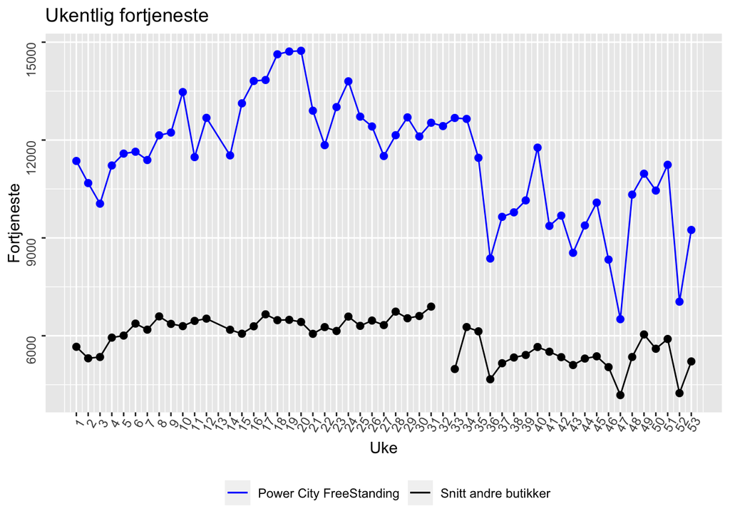

```r
Andre <- all %>% filter(Store_Num!="2") %>%
  select(Store_Name,Date,Week,Profit)

WeekSumAndre <-
  aggregate(Andre$Profit,
            by=list(Week=Andre$Week),
            FUN=sum) %>%
  rename(Profit = x)%>%
  mutate(Mean=Profit/9)

PCFSandre <- WeekSumPCFS %>%
  mutate(Mean = WeekSumAndre$Mean)

colors <- c("Power City FreeStanding" = "blue", "Snitt andre butikker" = "black")

PCFSandre %>%
  ggplot(aes(x=Week)) +
  geom_line(aes(y=Profit, color='Power City FreeStanding')) +
  geom_line(aes(y=Mean, color='Snitt andre butikker')) +
  geom_point(aes(x=Week,y=Profit), size=2, color='blue')+
  geom_point(aes(x=Week,y=Mean), size=2, color='black')+
  scale_x_continuous(breaks=seq(1, 53,1))+
  theme(axis.text.x = element_text(angle=60, hjust = 0.7))  +
  theme(axis.text.y = element_text(angle=90, vjust = 1))+
  labs(x = "Uke",
       y = "Fortjeneste",
       title = "Ukentlig fortjeneste",
       color='')+
  theme(legend.position = "bottom")+
  scale_color_manual(values=colors)
```

Vi velger også å vise hvordan denne avdelingens fortjeneste er, sammenlignet med snittet til de andre. Grafen her viser at Power City FreeStand har en høyere ukentlig fortjeneste enn snittet på resten. Slike grafer og tabeller er viktige for å vise ukentlig utvikling. En kan se på værdata for å se hvordan utslag være har hatt de forskjellige uken.

# Oppgave 3

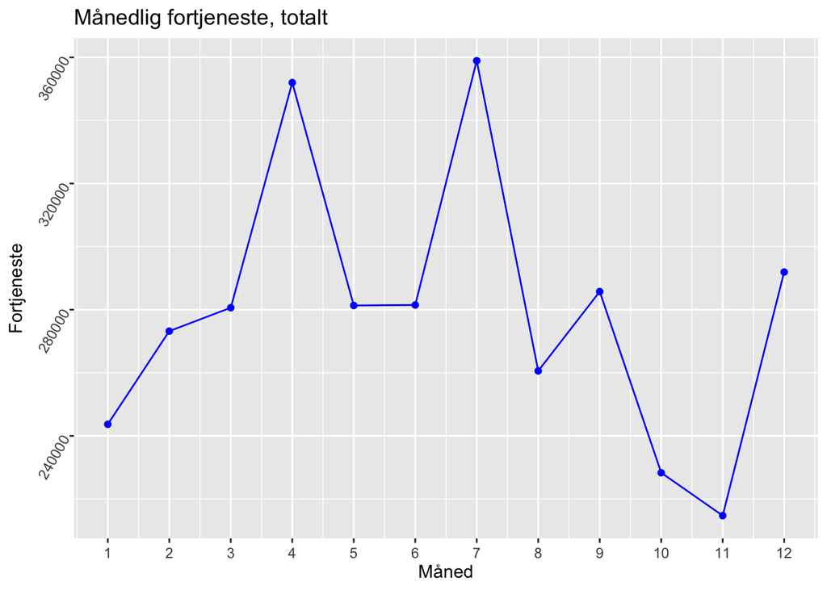

```r
MonthProfitTOT <- all %>%
  select(Month, Profit)

MonthProfitTOT <- MonthProfitTOT %>% group_by(Month) %>% summarise_each(funs(sum))
MonthProfitTOT <- drop_na(MonthProfitTOT)

MonthProfitTOT %>%
  ggplot(aes(x=Month, y=Profit)) +
  geom_line(color='blue')  +
  geom_point(size=1.5, color='blue')+
  scale_x_continuous(breaks=seq(1, 53,1))+
  theme(axis.text.x = element_text(vjust = 0.6)) +
  theme(axis.text.y = element_text(angle = 60, hjust = 1)) +
  labs(x = "Måned",
       y = "Fortjeneste",
       title = "Månedlig fortjeneste, totalt")
```

# Oppgave 4

```r
year_all <- all[all$Date >= "2012-04-01" & all$Date <= "2013-03-24",]

profit_all_stores <- year_all %>%
  group_by(Store_Name) %>%
  summarise(Profit = sum(Profit, na.rm = TRUE)) %>%
  arrange(desc(Profit))
```

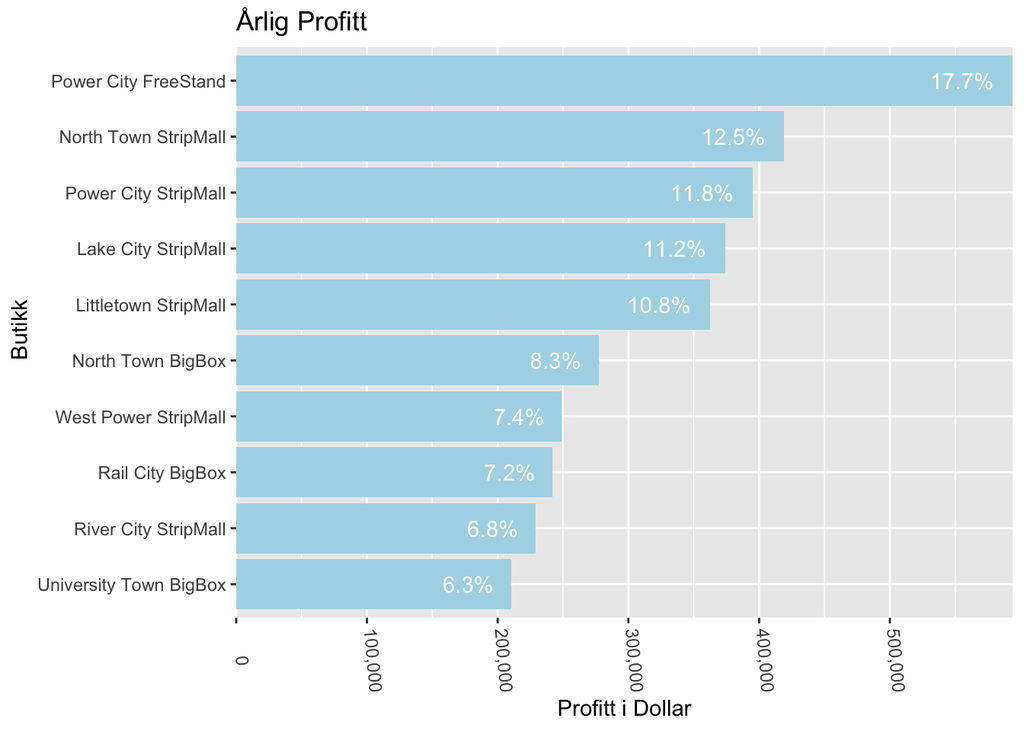

```r
profit_all_stores <- profit_all_stores %>%
  mutate(prosent = scales::percent(Profit / sum(Profit), accuracy = .1, trim = FALSE))

profit_all_stores %>%
  mutate(profit1=fct_reorder(Store_Name,Profit)) %>%
  ggplot(aes(profit1, Profit, fill = Store_Name)) +
  geom_col(fill = "lightblue") +
  theme(axis.text.x = element_text(angle=275, vjust = 0)) +
  geom_text(aes(label=prosent), hjust=1.3, color="white") +
  scale_y_continuous(expand = c(0,0), labels = scales::comma, breaks = seq(0,3000000,by=100000)) +
  coord_flip()+
  labs(title = "Årlig Profitt",
       x =" Butikk",
       y = "Profitt i Dollar")
```

```r
AppWichStoresAttributes$Annual_Rent_Estimate<-gsub(",","",as.character(AppWichStoresAttributes$Annual_Rent_Estimate))
AppWichStoresAttributes$Annual_Rent_Estimate <- as.numeric(as.character(AppWichStoresAttributes$Annual_Rent_Estimate))
```

```r
profit_all_stores_rent <- profit_all_stores %>%
  mutate(Annual_rent = AppWichStoresAttributes$Annual_Rent_Estimate,
         Profit_with_rent = Profit - Annual_rent,
         Renteprosent= scales::percent(Profit_with_rent / sum(Profit_with_rent), accuracy = .1, trim = FALSE))
```

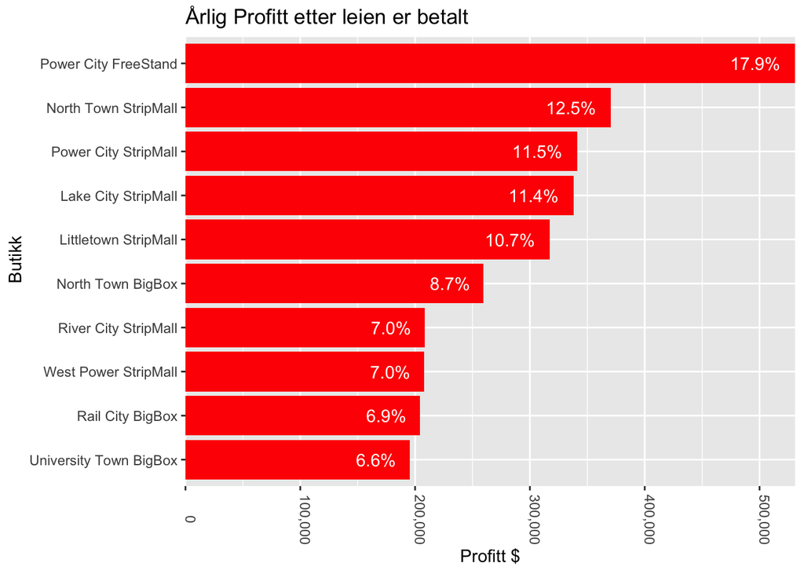

```r
profit_all_stores_rent %>%
  mutate(profit_rent=fct_reorder(Store_Name,Profit_with_rent)) %>%
  ggplot(aes(profit_rent, Profit_with_rent, fill = Store_Name)) +
  geom_col(fill = "red") +
  geom_text(aes(label=Renteprosent), hjust=1.3, color="white") +
  theme(axis.text.x = element_text(angle=270, vjust = 0)) +
  scale_y_continuous(expand = c(0,0), labels = scales::comma, breaks = seq(0,3000000,by=100000)) +
  coord_flip()+
  labs(title = "Årlig Profitt etter leien er betalt",
       x =" Butikk",
       y = "Profitt $")
```

Hvis vi trekker fra leien av lokalet der utsalgene holder til så får vi nye tall. PCFS har en omsetning på 531,085.5 dollar, som vil si 17,9% av de totale omsetningene. Power City topper altså statistikken både før og etter betalt leie.

Vi ser på bedrifter som er i nærheten av skoler. I figuren ser vi at tre av de fire øverste bedriftene går under denne kategorien. Utsalgene Power City Freestand, North Town Stripmall og Lake City Stripmall. Den siste bedriften er River City Stripmall, som er fjerde nederst på listen. I gjennomsnitt kan vi anslå at det vil være lukrativt å ha en bedrift i nærheten av en skole.

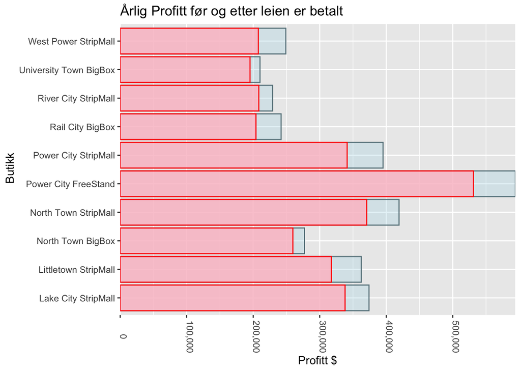

```r
ggplot(data=profit_all_stores_rent, aes(x=Store_Name)) +
  geom_bar(aes(y=Profit), stat="identity",
           position ="identity", alpha=.3, fill='lightblue', color='lightblue4') +
  geom_bar(aes(y=Profit_with_rent), stat="identity", position="identity", alpha=.8,
           fill='pink', color='red')+
  theme(axis.text.x = element_text(angle=270, vjust = 0), legend.position = "top") +
  scale_y_continuous(expand = c(0,0), labels = scales::comma,
                     breaks = seq(0,3000000,by=100000)) +
  coord_flip()+
  labs(title = "Årlig Profitt før og etter leien er betalt",
       x =" Butikk",
       y = "Profitt $")
```

```r
profit_all_stores_rent
```

```
## # A tibble: 10 × 6
##    Store_Name           Profit prosent Annual_rent Profit_with_rent Renteprosent
##    <chr>                 <dbl> <chr>         <dbl>            <dbl> <chr>
##  1 Power City FreeStand 5.94e5 "17.7%"       63000          531086. "17.9%"
##  2 North Town StripMall 4.19e5 "12.5%"       48600          370626. "12.5%"
##  3 Power City StripMall 3.95e5 "11.8%"       54000          341206. "11.5%"
##  4 Lake City StripMall  3.74e5 "11.2%"       36000          338082. "11.4%"
##  5 Littletown StripMall 3.62e5 "10.8%"       45000          317474. "10.7%"
##  6 North Town BigBox    2.77e5 " 8.3%"       17500          259646. " 8.7%"
##  7 West Power StripMall 2.49e5 " 7.4%"       41400          207682. " 7.0%"
##  8 Rail City BigBox     2.42e5 " 7.2%"       37800          204126. " 6.9%"
##  9 River City StripMall 2.29e5 " 6.8%"       20700          208432. " 7.0%"
## 10 University Town Big… 2.10e5 " 6.3%"       15000          195219. " 6.6%"
```

```r
county_employment$County_Employed<-gsub(",","",as.character(county_employment$County_Employed))
county_employment$County_Employed <- as.numeric(as.character(county_employment$County_Employed))

county_employment$County_Unemployed<-gsub(",","",as.character(county_employment$County_Unemployed))
county_employment$County_Unemployed <- as.numeric(as.character(county_employment$County_Unemployed))
county_employment %>% arrange(desc(County_Labor_Force))
```

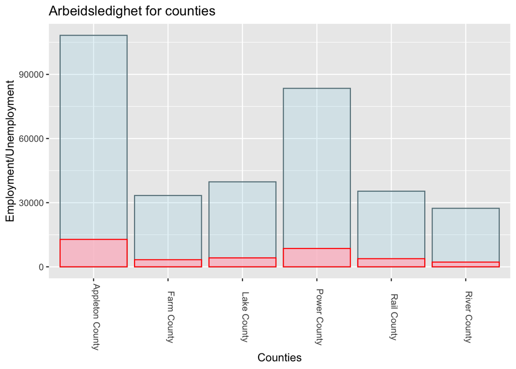

```r
ggplot(data=county_employment, aes(x=County_Name)) +
  geom_bar(aes(y=County_Employed), stat="identity", position ="identity",
           alpha=.3, fill='lightblue', color='lightblue4') +
  geom_bar(aes(y=County_Unemployed), stat="identity", position="identity",
           alpha=.8, fill='pink', color='red')+
  theme(axis.text.x = element_text(angle=270, vjust = 0), legend.position = c(0,1),
        legend.justification = c(0,1)) +
  labs(title = "Arbeidsledighet for counties",
       x ="Counties",
       y = "Employment/Unemployment")
```

```r
county_employment
```

```
##       County_Name County_Labor_Force County_Employed County_Unemployed
## 1 Appleton County            121,082          108267             12815
## 2     Farm County             36,674           33354              3320
## 3     Lake County             43,914           39740              4174
## 4    Power County             92,041           83467              8574
## 5     Rail County             39,167           35366              3801
## 6    River County             29,564           27361              2203
##   County_Unemployment_Rate
## 1                     10.6
## 2                      9.1
## 3                      9.5
## 4                      9.3
## 5                      9.7
## 6                      7.5
```

Den tilgjengelige arbeidskraften er også avgjørende. På denne figuren ser vi antall arbeidere sammenlignet med arbeidsledige innbyggere. Høy arbeidsledighet betyr at et nytt utsalg lettere kan ha tilgang til arbeidskraft og ansatte. Høy arbeidsledighet fører også til lav lønnsvekst. Dette kan bedriften spare penger på.

Dersom konsernlederen ønsker å starte et nytt utsalg så er det masse data vi kan henvise til for å rådgive konsernlederen til et gunstig utsalgssted. Vi vil anbefale Appelton County som er det mest profitable fylket å starte bedrift i, og byen å starte utsalgsstedet bør være Littletown . Ut ifra hva dataen sier så har vi observert at Littletown har størt potensial. I motsettning til Power City så har ikke Littletown noe eksisterende utsalgssted som er freestand. Power City har to av de tre mest lukrative bedriftene, som betyr at det kanskje ikke er nødvendig med en til. Som vi ser i dataen så er det betydelig mer lukrativt å ha en freestand bedrift enn en plassert på et stripmall eller bigbox. Freestand er en del dyrere å leie enn sammenliknet med bigbox og stripmall, men den potensielle inntekten kan kompensere for dette. Med den dataen vi har analysert kommer vi fram til et par poeng. For et nytt utsalgsted ville det vært lukrativt å åpne for salg i en by med høy befolkning og høy arbeidsledighet. Det kommer av den lette tilgangen på arbeidskraft og mange potensielle kunder. Vi ser også ut ifra dataen at utsalget burde også være i nærheten av en skole i tillegg til drive-through, siden begge øker omsetningen.